# BIOST 578 - HW4

Kelsey Grinde

3/5/2015

# Instructions:

The goal of this assignment is to analyze the RNA-seq data in the following paper:

Henn, A. D. et al. High-resolution temporal response patterns to influenza vaccine reveal a distinct human plasma cell gene signature. Scientific Reports 3, 2327 (2013).

# Set Up

First we’ll download and/or install the necessary packages.

```r
suppressMessages(library(data.table))
suppressMessages(library(limma))
suppressMessages(library(edgeR))
suppressMessages(library(GEOquery))
suppressMessages(library(pheatmap))
suppressMessages(library(GSEABase))
suppressMessages(library(BiocInstaller))
```

# Get the data:

First we need to get the data from GEO. This code is taken from the class lecture slides.

```r
# get data, send to Data/GEO folder
gd <- getGEO("GSE45735", destdir = "Data/GEO/")
```

```
## ftp://ftp.ncbi.nlm.nih.gov/geo/series/GSE45nnn/GSE45735/matrix/
## Found 1 file(s)
## GSE45735_series_matrix.txt.gz
## Using locally cached version: Data/GEO//GSE45735_series_matrix.txt.gz
## Using locally cached version of GPL10999 found here:
## Data/GEO//GPL10999.soft
```

```r
# get sample data
pd <- pData(gd[[1]])
# get supplementary files
getGEOSuppFiles("GSE45735", makeDirectory = FALSE, baseDir = "Data/GEO/")
```

```
## ftp://ftp.ncbi.nlm.nih.gov/geo/series/GSE45nnn/GSE45735/suppl/
```

```r
## Do some clean-up
files <- list.files(path = "Data/GEO/", pattern = "GSE45735_T.*.gz",
    full.names = TRUE)
# Read in gzipped, tab-delim supplementary files
file_list <- lapply(files, read.table, sep = "\t", header = TRUE)
# Subset to only rows where gene contains only
# non-space characters This addresses problems with T14 file
# containing 28 invalid rows at end of file
file_list <- lapply(file_list, function(file_list) subset(file_list,
    grepl("^[^[:space:]]+$", Gene)))
# Remove duplicated rows
file_list_unique <- lapply(file_list, function(x) {
    x <- x[!duplicated(x$Gene), ]
    x <- x[order(x$Gene), ]
    rownames(x) <- x$Gene
    x[, -1]
})
# Take the intersection of all genes
gene_list <- Reduce(intersect, lapply(file_list_unique, rownames))
file_list_unique <- lapply(file_list_unique, "[", gene_list, )
matrix <- as.matrix(do.call(cbind, file_list_unique))
# Clean up the pData, too
pd_small <- pd[!grepl("T13_Day8", pd$title), ]
pd_small$Day <- sapply(strsplit(gsub(" \\[PBMC\\]", "", pd_small$title),
    "_"), "[", 2)
pd_small$subject <- sapply(strsplit(gsub(" \\[PBMC\\]", "", pd_small$title),
    "_"), "[", 1)
colnames(matrix) <- rownames(pd_small)
```

# Use `voom` and `limma` to find differentially expressed genes

Now we will look for genes that are differentially expressed at each time point compared to baseline using `voom` and `limma`. We’ll control FDR at a cutoff of 0.01. This code is largely inspired by code from the class lecture slides.

```r
# creat an eSet, add one to the count
new_set <- ExpressionSet(assayData = matrix + 1)
pData(new_set) <- pd_small

# set up design matrix
design <- model.matrix(~subject + Day, new_set)

# run voom
new_set_voom <- voom(new_set, design = design)

# fit LIMMA
lm <- lmFit(new_set_voom, design)

# get moderated t-stats
eb <- eBayes(lm)

# look for differentially expressed genes at day 1, FDR 0.01
top_day1 <- topTable(eb, coef = "DayDay1", number = Inf, adjust.method="BH",
                     p.value = 0.01,sort.by='none')
# at Day 2
top_day2 <- topTable(eb, coef = "DayDay2", number = Inf, adjust.method="BH", p.value = 0.01)
# at Day 3
top_day3 <- topTable(eb, coef = "DayDay3", number = Inf, adjust.method="BH", p.value = 0.01)
# at Day 4
top_day4 <- topTable(eb, coef = "DayDay4", number = Inf, adjust.method="BH", p.value = 0.01)
# at Day 5
top_day5 <- topTable(eb, coef = "DayDay5", number = Inf, adjust.method="BH", p.value = 0.01)
# at Day 6
top_day6 <- topTable(eb, coef = "DayDay6", number = Inf, adjust.method="BH", p.value = 0.01)
# at Day 7
top_day7 <- topTable(eb, coef = "DayDay7", number = Inf, adjust.method="BH", p.value = 0.01)
# at Day 8
top_day8 <- topTable(eb, coef = "DayDay8", number = Inf, adjust.method="BH", p.value = 0.01)
# at Day 9
top_day9 <- topTable(eb, coef = "DayDay9", number = Inf, adjust.method="BH", p.value = 0.01)
# at Day 10
top_day10 <- topTable(eb, coef = "DayDay10", number = Inf, adjust.method="BH", p.value = 0.01)
```

When controlling FDR at a cutoff of 0.01, we find no significantly differentially expressed genes at days 2, 4, 5, 6, 7, 8, 9, or 10. At day 1 we find 58 significantly differentially expressed genes and at day 3 we find 1.

# Display results using `pheatmap`

Then we will display our results using `pheatmap` to show the log-fold-change for the differentially expressed genes, grouped by time point. I restrict the figure to only showing the log fold changes for the 58 genes that were significantly differentially expressed at Day 1.

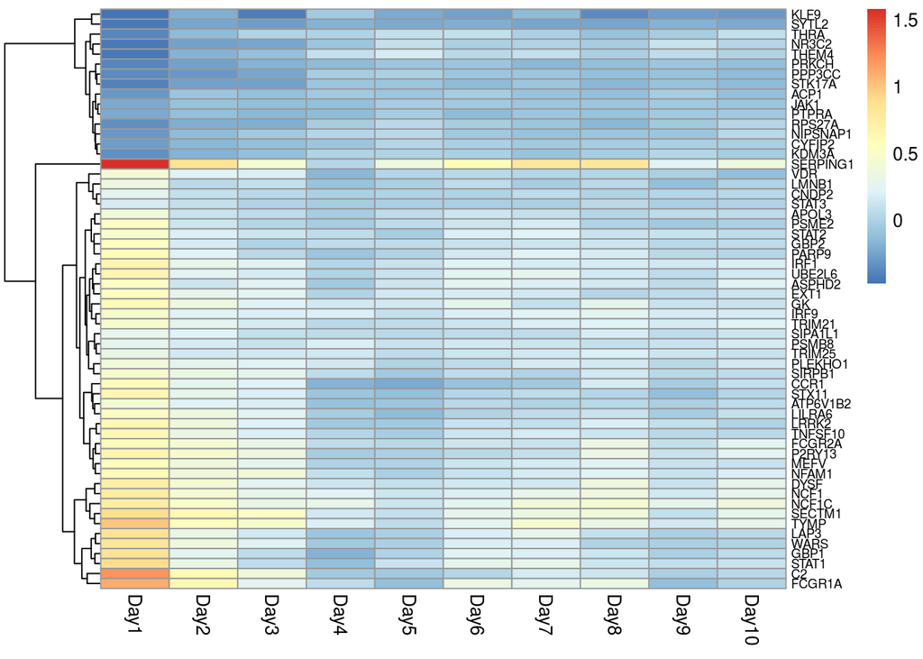

```r
# log fold change for all days, with just the genes significantly DE at day 1
day1 <- top_day1$logFC
day2 <- topTable(eb, coef = "DayDay2", number = Inf, adjust.method = "BH",sort.by='none')
day2 <- subset(day2, rownames(day2) %in% rownames(top_day1))
day3 <- topTable(eb, coef = "DayDay3", number = Inf, adjust.method="BH",sort.by='none')
day3 <- subset(day3, rownames(day3) %in% rownames(top_day1))
day4 <- topTable(eb, coef = "DayDay4", number = Inf, adjust.method="BH",sort.by='none')
day4 <- subset(day4, rownames(day4) %in% rownames(top_day1))
day5 <- topTable(eb, coef = "DayDay5", number = Inf, adjust.method="BH",sort.by='none')
day5 <- subset(day5, rownames(day5) %in% rownames(top_day1))
day6 <- topTable(eb, coef = "DayDay6", number = Inf, adjust.method="BH",sort.by='none')
day6 <- subset(day6, rownames(day6) %in% rownames(top_day1))
day7 <- topTable(eb, coef = "DayDay7", number = Inf, adjust.method="BH",sort.by='none')
day7 <- subset(day7, rownames(day7) %in% rownames(top_day1))
day8 <- topTable(eb, coef = "DayDay8", number = Inf, adjust.method="BH",sort.by='none')
day8 <- subset(day8, rownames(day8) %in% rownames(top_day1))
day9 <- topTable(eb, coef = "DayDay9", number = Inf, adjust.method="BH",sort.by='none')
day9 <- subset(day9, rownames(day9) %in% rownames(top_day1))
day10 <- topTable(eb, coef = "DayDay10", number = Inf, adjust.method="BH",sort.by='none')
day10 <- subset(day10, rownames(day10) %in% rownames(top_day1))

# get log fold changes into matrix so we can make heat map
lfc_matrix <- matrix(NA,nrow=58,ncol=10)
lfc_matrix[,1] <- day1
lfc_matrix[,2] <- day2$logFC
lfc_matrix[,3] <- day3$logFC
lfc_matrix[,4] <- day4$logFC
lfc_matrix[,5] <- day5$logFC
lfc_matrix[,6] <- day6$logFC
lfc_matrix[,7] <- day7$logFC
lfc_matrix[,8] <- day8$logFC
lfc_matrix[,9] <- day9$logFC
lfc_matrix[,10] <- day10$logFC
colnames(lfc_matrix) <- paste('Day',1:10,sep= '')
rownames(lfc_matrix) <- rownames(top_day1)

# make heatmap using pheatmap
pheatmap(lfc_matrix,cluster_cols = F,fontsize_row = 7)
```

# Perform GSEA

First we convert the gene sets into gene indices. I got the `c2.all.v4.0.symbols.gmt` file from the BIOST-578 class repo. Then we specify our contrasts.

```r
## Get gene indices
c2_set <- getGmt("GSEA-sets/c2.all.v4.0.symbols.gmt")
gene_ids <- geneIds(c2_set)
# Camera requires gene-indices.  Which function to use will
# depend on which version of limma you have.
# http://bioconductor.org/packages/release/bioc/news/limma/NEWS
# 'symbols2indices() renamed to ids2indices().'
library(limma)
if (exists("ids2indices")) {
    sets_indices <- ids2indices(gene_ids, rownames(new_set))
}
if (exists("symbols2indices")) {
    sets_indices <- symbols2indices(gene_ids, rownames(new_set))
}

## Make contrasts
# Note that camera works on voom objects
res <- vector("list", length = 10)
for (i in 1:10) {
    contrast <- paste0("DayDay", i)
    cont_matrix <- makeContrasts(contrast, levels = design)
    res[[i]] <- camera(new_set_voom, sets_indices, design = design,
        contrast = cont_matrix, sort = FALSE)
}
```

# Display results using pheatmap

We will also display our GSEA results using `pheatmap`, again grouping results by timepoint in the heat map.

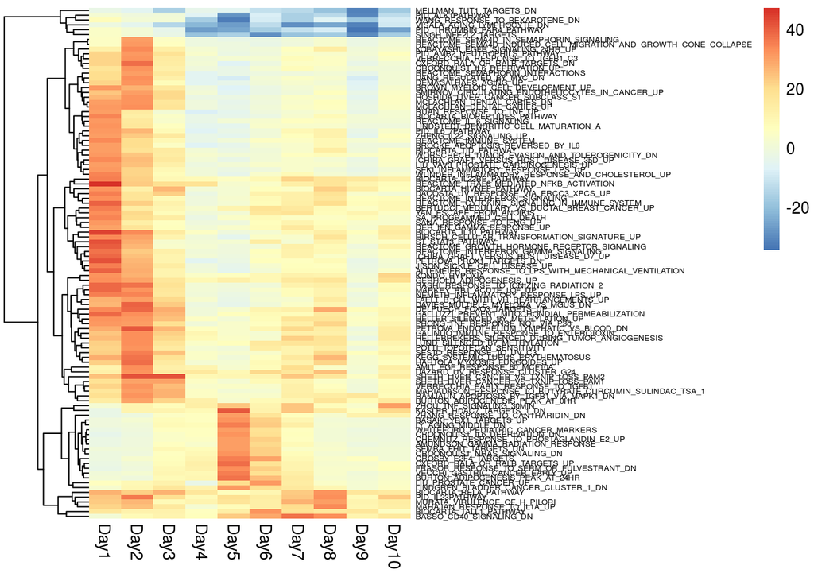

```r
PValue <- sapply(res, function(x) {
    ifelse(x$Direction == "Up", -10 * log10(x$PValue), 10 * log10(x$PValue))
})
rownames(PValue) <- rownames(res[[1]])
PValue_max <- rowMax(abs(PValue))
PValue_small <- PValue[PValue_max > 30, ]
anno <- data.frame(Time = paste0("Day", 1:10))
rownames(anno) <- colnames(PValue_small) <- paste0("Day", 1:10)

# reproduce figure in lecture notes
colnames(PValue_small) <- paste0("Day",1:10)
pheatmap(PValue_small,cluster_cols = F,fontsize_row=5)
```